# Презентация по лабораторной работе №12

Дисциплина: операционные системы

Лобанова П. И.

Российский университет дружбы народов, Москва, Россия

29.04.2023

# Информация

## Докладчик

- Лобанова Полина Иннокентьевна
- учащаяся факультета физико-математических и естественных наук
- учащаяся направления “Компьютерные и информационные науки”
- Российский университет дружбы народов
- polla-2004@mail.ru

# Цель работы

Изучить основы программирования в оболочке ОС UNIX. Научиться писать более сложные командные файлы с использованием логических управляющих конструкций и циклов.

# Ход работы

## Задание 1

Написать командный файл, реализующий упрощённый механизм семафоров. Командный файл должен в течение некоторого времени t1 дожидаться освобождения ресурса, выдавая об этом сообщение, а дождавшись его освобождения, использовать его в течение некоторого времени t2<>t1, также выдавая информацию о том, что ресурс используется соответствующим командным файлом (процессом).

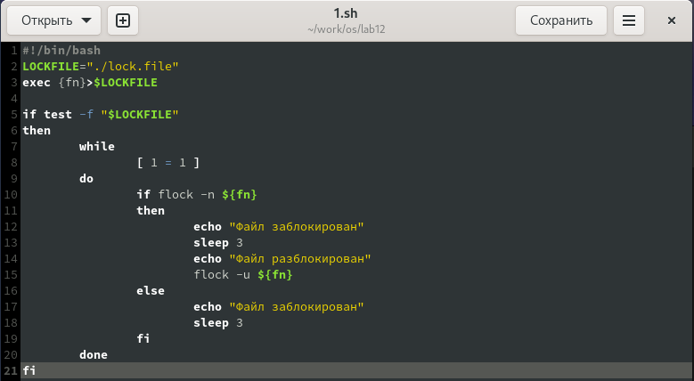

*Текст скрипта.*

## Результат

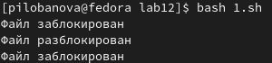

*Результат.*

## Задание 2

Реализовать команду man с помощью командного файла. Изучите содержимое каталога /usr/share/man/man1. В нем находятся архивы текстовых файлов, содержащих справку по большинству установленных в системе программ и команд. Каждый архив можно открыть командой less сразу же просмотрев содержимое справки. Командный файл должен получать в виде аргумента командной строки название команды и в виде результата выдавать справку об этой команде или сообщение об отсутствии справки, если соответствующего файла нет в каталоге man1.

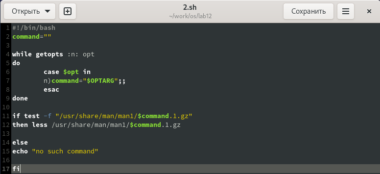

*Текст скрипта.*

## Результат

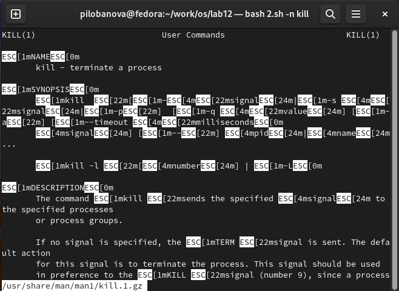

*Результат.*

## Задание 3

Используя встроенную переменную $RANDOM, напишите командный файл, генерирующий случайную последовательность букв латинского алфавита. Учтите, что $RANDOM выдаёт псевдослучайные числа в диапазоне от 0 до 32767.

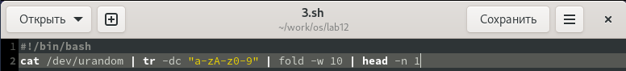

*Текст скрипта.*

## Результат

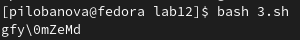

*Результат.*

# Контрольные вопросы

1. Найдите синтаксическую ошибку в следующей строке: 1 while [$1 != “exit”]
2. Как объединить (конкатенация) несколько строк в одну?
3. Найдите информацию об утилите seq. Какими иными способами можно реализовать её функционал при программировании на bash?
4. Какой результат даст вычисление выражения $((10/3))?
5. Укажите кратко основные отличия командной оболочки zsh от bash.
6. Проверьте, верен ли синтаксис данной конструкции 1 for ((a=1; a <= LIMIT; a++))
7. Сравните язык bash с какими-либо языками программирования. Какие преимущества у bash по сравнению с ними? Какие недостатки?

# Вывод

Я научилась писать более сложные командные файлы с использованием логических управляющих конструкций и циклов.